# Young People Survey

Darian-Florian Voda

2023-06-21

```r
library(ggplot2)
library(dplyr)
library(ggrepel)
library(tidyverse)
```

## R Data Visualization Project: Young People Survey

## Information about the main dataset (responses)

- In 2013, students of the Statistics class at FSEV UK were asked to invite their friends to participate in this survey.
- The data file (responses.csv) consists of 1010 rows and 150 columns (139 integer and 11 categorical).
- For convenience, the original variable names were shortened in the data file.
- File columns.csv represents the dataset for the shortenings made for each variable name
- All participants were of Slovakian nationality (the questionnaire was later translated in English), aged between 15-30.

The variables can be split into the following groups: - Music preferences (19 items) - Movie preferences (12 items) - Hobbies & interests (32 items) - Phobias (10 items) - Health habits (3 items) - Personality traits, views on life, & opinions (57 items) - Spending habits (7 items) - Demographics (10 items)

## Main Question: How to effectively visualize a lot of variables in order to gain some meaningful insights from the data?

### Example of a specific category

#### MUSIC PREFERENCES

1. I enjoy listening to music.: Strongly disagree 1-2-3-4-5 Strongly agree (integer)
2. I prefer.: Slow paced music 1-2-3-4-5 Fast paced music (integer)
3. Dance, Disco, Funk: Don’t enjoy at all 1-2-3-4-5 Enjoy very much (integer)
4. Folk music: Don’t enjoy at all 1-2-3-4-5 Enjoy very much (integer)
5. Country: Don’t enjoy at all 1-2-3-4-5 Enjoy very much (integer)
6. Classical: Don’t enjoy at all 1-2-3-4-5 Enjoy very much (integer)
7. Musicals: Don’t enjoy at all 1-2-3-4-5 Enjoy very much (integer)
8. Pop: Don’t enjoy at all 1-2-3-4-5 Enjoy very much (integer)
9. Rock: Don’t enjoy at all 1-2-3-4-5 Enjoy very much (integer)
10. Metal, Hard rock: Don’t enjoy at all 1-2-3-4-5 Enjoy very much (integer)

### Import data

```r
data = read.csv("responses.csv")
columns = read.csv("columns.csv")

head(data)
```

|  | Music | Slow.songs.or.fast.songs | Dance | Folk | Country | Classical.music | Musical | Pop | Rock | Metal.or.Hardrock | Punk | Hiphop..Rap | Reggae..Ska | Swing..Jazz | Rock.n.roll | Alternative | Latino | Techno..Trance | Opera | Movies | Horror | Thriller | Comedy | Romantic | Sci.fi | War | Fantasy.Fairy.tales | Animated | Documentary | … |
| --- | --- | --- | --- | --- | --- | --- | --- | --- | --- | --- | --- | --- | --- | --- | --- | --- | --- | --- | --- | --- | --- | --- | --- | --- | --- | --- | --- | --- | --- | --- |
| 1 | 5 | 3 | 2 | 1 | 2 | 2 | 1 | 5 | 5 | 1 | 1 | 1 | 1 | 1 | 3 | 1 | 1 | 1 | 1 | 5 | 4 | 2 | 5 | 4 | 4 | 1 | 5 | 5 | 3 | … |
| 2 | 4 | 4 | 2 | 1 | 1 | 1 | 2 | 3 | 5 | 4 | 4 | 1 | 3 | 1 | 4 | 4 | 2 | 1 | 1 | 5 | 2 | 2 | 4 | 3 | 4 | 1 | 3 | 5 | 4 | … |
| 3 | 5 | 5 | 2 | 2 | 3 | 4 | 5 | 3 | 5 | 3 | 4 | 1 | 4 | 3 | 5 | 5 | 5 | 1 | 3 | 5 | 3 | 4 | 4 | 2 | 4 | 2 | 5 | 5 | 2 | … |
| 4 | 5 | 3 | 2 | 1 | 1 | 1 | 1 | 2 | 2 | 1 | 4 | 2 | 2 | 1 | 2 | 5 | 1 | 2 | 1 | 5 | 4 | 4 | 3 | 3 | 4 | 3 | 1 | 2 | 5 | … |
| 5 | 5 | 3 | 4 | 3 | 2 | 4 | 3 | 5 | 3 | 1 | 2 | 5 | 3 | 2 | 1 | 2 | 4 | 2 | 2 | 5 | 4 | 4 | 5 | 2 | 3 | 3 | 4 | 4 | 3 | … |
| 6 | 5 | 3 | 2 | 3 | 2 | 3 | 3 | 2 | 5 | 5 | 3 | 4 | 3 | 4 | 4 | 5 | 3 | 1 | 3 | 5 | 5 | 5 | 5 | 2 | 3 | 3 | 4 | 3 | 3 | … |

### See columns data

```r
head(columns)
```

|  | original | short |
| --- | --- | --- |
| 1 | I enjoy listening to music. | Music |
| 2 | I prefer. | Slow songs or fast songs |
| 3 | Dance, Disco, Funk | Dance |
| 4 | Folk music | Folk |
| 5 | Country | Country |
| 6 | Classical | Classical music |

## Exploratory Data Analysis (EDA)

Firstly, we will split each category in dataframes for a better management

```r
# Split into DFs
music_dataframe = data.frame(data[1:19])

movies_dataframe = data.frame(data[20:31])

hobbies_dataframe = data.frame(data[32:63])

phobias_dataframe = data.frame(data[64:73])

health_habits_dataframe = data.frame(data[74:76])

personality_dataframe = data.frame(data[78:133])

spendings_dataframe = data.frame(data[134:140])

demographics_dataframe = data.frame(data[141:150])
```

Now, we will take a look how much people enjoy the **Music** in general

Firstly create a dataframe of the frequencies for the specific question

```r
overall_music = music_dataframe %>%
  group_by(Music) %>%
  summarise(counts = n())

overall_music
```

| Music | counts |
| --- | --- |
| 1 | 9 |
| 2 | 11 |
| 3 | 36 |
| 4 | 129 |
| 5 | 822 |
| NA | 3 |

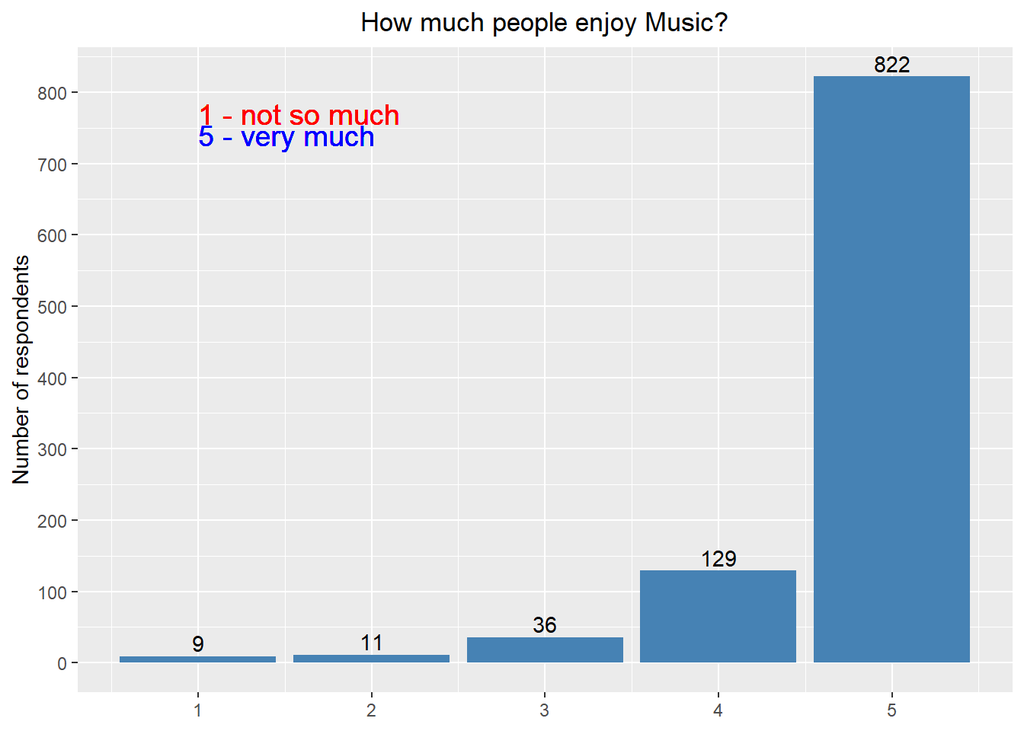

```r
overall_music_plot = ggplot(overall_music, aes(x = Music, y = counts, fill=counts)) +
  geom_bar(stat = "identity", fill="steelblue")+
  geom_text(aes(label= counts), vjust = -0.3)+
  theme(axis.title.x = element_blank(),
        plot.title = element_text(hjust = 0.5))+
  labs(y="Number of respondents")+
  ggtitle("How much people enjoy Music?")+
  geom_text(x=1, y=770, label="1 - not so much", color="red", hjust = 0, size = 5)+
  geom_text(x=1, y=740, label="5 - very much", color = "blue", hjust = 0, size = 5)+
  scale_y_continuous(breaks=round(seq(0, max(overall_music$counts), by=100), 1))

overall_music_plot
```

## Idea:

- Create an an interactive graph that is based on the specific things (Music, Movies, etc)
- Then on the lower side of this mini-infograph you can expand the other things for the other categories
- Create Pie charts for Genres of music/movie/etc